# Week 10 Assignment

Cheryl Bowersox IS 605 - 1 4/4/15

======================================================== ## Problem Set 1

### Create Martrix A for 6 site universe

$A_{ij} = \frac{1}{|P_i|}$ if link from i to j exists, 0 otherwise

```r
library(igraph)
# function for converting matrix format from R
convmat <- function(X){
  M <- paste("\\begin{bmatrix}","\n")

  i = 1
  n = nrow(X)
  if(is.null(n)){
    n <- length(X)
    while(i <= n){
       M <- paste(M, paste(round(X[i],4), collapse = " & "),"\\\\ \n")
       i = i + 1
    }
  }else{
    while(i <= n){
       M <- paste(M, paste(round(X[i,],4), collapse = " & "),"\\\\ \n")
       i = i + 1
    }
  }
  M <- paste(M, "\\end{bmatrix}","\n", collapse = "")
  return (M)
}
```

```r
#define A, 6 X 6 matrix

A = diag(6)
A[,1] = c(0, .5, .5, 0, 0, 0)
A[,2] = c(0, 0, 1, 0, 0,0)
A[,3] = c(.25, .25, 0, 0, .25, .25)
A[,4] = c(0,0,0,0,.5, .5)
A[,5] = c(0, 0, 0, .5, 0, .5)
A[,6] = c(0,0,.5,.5,0, 0)
```

Matrix for graph is

$A = \begin{bmatrix} 0 & 0 & 0.25 & 0 & 0 & 0 \\ 0.5 & 0 & 0.25 & 0 & 0 & 0 \\ 0.5 & 1 & 0 & 0 & 0 & 0.5 \\ 0 & 0 & 0 & 0 & 0.5 & 0.5 \\ 0 & 0 & 0.25 & 0.5 & 0 & 0 \\ 0 & 0 & 0.25 & 0.5 & 0.5 & 0 \\ \end{bmatrix} \\$

### Matrix B with decay

$B = d\times A + \frac{1-d}{n}$ d is the probablity a user will use a link on the current page

1-d being the probablity the user will jump to another page

n is the finite probablity of reaching a web page at random

In this case setting d = .85 and n = 6 gives

```r
d <-.85
n <- 6
B <- d * A + (1-d)/n
```

$B = \begin{bmatrix} 0.025 & 0.025 & 0.2375 & 0.025 & 0.025 & 0.025 \\ 0.45 & 0.025 & 0.2375 & 0.025 & 0.025 & 0.025 \\ 0.45 & 0.875 & 0.025 & 0.025 & 0.025 & 0.45 \\ 0.025 & 0.025 & 0.025 & 0.025 & 0.45 & 0.45 \\ 0.025 & 0.025 & 0.2375 & 0.45 & 0.025 & 0.025 \\ 0.025 & 0.025 & 0.2375 & 0.45 & 0.45 & 0.025 \\ \end{bmatrix} \\$

### converging for large number of iterations

k is the number of iterations

r is uniform rank vector

$r = B^k\times r$ for sufficiently large k

setting k to 10, 50, 100 gives:

```r
i <- 1
r = rep(1/n, n)  # intial value for r is uniform distribution
i = 1
while(i <= 10){
  r <- B %*% r
  i <- i +1
  }
k10 <- r

while(i <= 50){
  r <- B %*% r
  i <- i +1
  }
k50 <- r

while(i <= 100){
  r <- B %*% r
  i <- i +1
  }
k100 <- r
```

when k is 10

$r = \begin{bmatrix} 0.0774 \\ 0.1103 \\ 0.2464 \\ 0.1863 \\ 0.1566 \\ 0.2231 \\ \end{bmatrix} \\$

when k is 50

$r = \begin{bmatrix} 0.0774 \\ 0.1102 \\ 0.2464 \\ 0.1864 \\ 0.1566 \\ 0.2231 \\ \end{bmatrix} \\$

when k is 100

$r = \begin{bmatrix} 0.0774 \\ 0.1102 \\ 0.2464 \\ 0.1864 \\ 0.1566 \\ 0.2231 \\ \end{bmatrix} \\$

r is converging for suffienctly large k:

$r50 - r100 = \begin{bmatrix} 0 \\ 0 \\ 0 \\ 0 \\ 0 \\ 0 \\ \end{bmatrix} \\$

### eigenvalues and eigenvectors of B

```r
evalB <- eigen(B)$values
evecB <- eigen(B)$vectors
```

1 is an eigenvalue of B: $\begin{bmatrix} 1+0i \\ 0.5064+0i \\ -0.425+0i \\ -0.425+0i \\ -0.2532+0.1081i \\ -0.2532-0.1081i \\ \end{bmatrix} \\$

1 is the maximum eigenvalue of B: $1\\$

Corresponding eigenvector of B is: $\begin{bmatrix} -0.1785 \\ -0.2543 \\ -0.5685 \\ -0.43 \\ -0.3612 \\ -0.5147 \\ \end{bmatrix} \\$

which is scaler multiple of $\begin{bmatrix} 0.0774 \\ 0.1102 \\ 0.2464 \\ 0.1864 \\ 0.1566 \\ 0.2231 \\ \end{bmatrix} \\$

```r
evalB1 <- Re(evalB[1])
dif<- Re((evecB[,1]/k100 )[1])
```

$for \lambda = 1\\ \vec{X} = \begin{bmatrix} -0.1785 \\ -0.2543 \\ -0.5685 \\ -0.43 \\ -0.3612 \\ -0.5147 \\ \end{bmatrix} = -2.307202 \times \begin{bmatrix} 0.0774 \\ 0.1102 \\ 0.2464 \\ 0.1864 \\ 0.1566 \\ 0.2231 \\ \end{bmatrix} = \begin{bmatrix} -0.1785 \\ -0.2543 \\ -0.5685 \\ -0.43 \\ -0.3612 \\ -0.5147 \\ \end{bmatrix} \\$

### using igraph and page.rank package

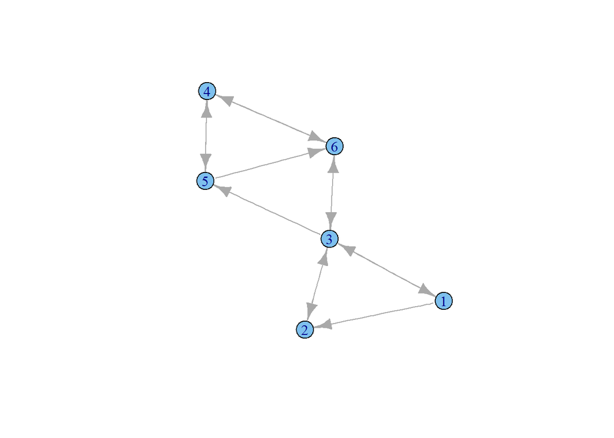

```r
g <- graph.formula(1-+2,1+-+3, 3 +-+ 2, 3+-+6, 3-+5, 6 +-+4, 5-+6, 5 +-+ 4)
rnew  <- page.rank(g, directed = TRUE)$vector
rnew <- matrix(rnew[order(names(rnew))])

plot(g)
```

The r vector calculated by the page.rank function is the same as that calculated using 100 itterations of matrix B

New r calculated using page.rank = $\begin{bmatrix} 0.0774 \\ 0.1102 \\ 0.2464 \\ 0.1864 \\ 0.1566 \\ 0.2231 \\ \end{bmatrix} \\$ r calculated using itterations of B = $\begin{bmatrix} 0.0774 \\ 0.1102 \\ 0.2464 \\ 0.1864 \\ 0.1566 \\ 0.2231 \\ \end{bmatrix} \\$